# Case Study: Cyclistic bikeshare data analysis

James Paul Pulayan

2023-01-28

## **Ask**

This phase of the data process is about identifying the problems which are relevant to the stakeholders. These challenges shall be the guide in carrying out each of the steps of the data processing.

### Background

This case study is one of the optional projects of track 1 of the “Google Data Analytics Capstone: Complete a Case Study”. The course is the last part of the Google Data Analytics Professional Certification. This case study was described to be similar to case studies conducted on job interviews. The business task, data set and collections of identified deliverable are specified by the course and must be presented to expected stakeholders. Once done with the case study, it can be included in the portfolio to demonstrate data analytics related skills for future job interviews.

In the process of doing this case study, real-world tasks of a junior data analyst shall be completed. In answering key business questions for the devised company Cyclistic, the data analysis process: ask, prepare, process, analyze, share and act shall be followed.

### Scenario

I am part of the marketing analyst team of Cyclistic, a bike-share company in Chicago, as a junior data analyst. The director, Lily Moreno, believes that maximizing the number of annual memberships is relevant in the eventual success of the company. The finance analysts inferred that annual members are much more profitable than casual riders.

The bike-share program of Cyclistic features more than 5800 bicycles and 600 dock stations as well as assistive bikes like reclining bikes, hand tricycles and cargo bikes. About 8% of the riders utilizes the assistive bikes. Majority of the bikers use bikes for recreation and fun and about 30% use bikes for commuting.

The Cyclistic executive team shall determine the suitability of the recommended marketing program.

### Business use case

Guide questions for the business task:

How do annual members and casual riders use Cyclistic bikes differently? (The question asked by Moreno)

**Business task**

Formulate top 3 recommendations on how casual riders may upgrade to annual membership by understanding their differences from the result of the analysis of the historical data.

## **Data preparation**

The data source provides monthly data of users with the latest data dating to November of 2022.

### Setting up environment

```r
library(tidyverse) #For cleaning data
library(dplyr) #Data manipulation
library(skimr) #Data summary
library(lubridate) #Date manipulation
library(ggpattern) #for fill pattern
library(RColorBrewer) #Color palettes
library(rmarkdown) #documentation
```

```r
tripdata_202112 <- read_csv("202112-divvy-tripdata.csv") #Dec, 2021
tripdata_202201 <- read_csv("202201-divvy-tripdata.csv") #Jan, 2022
tripdata_202202 <- read_csv("202202-divvy-tripdata.csv") #Feb, 2022
tripdata_202203 <- read_csv("202203-divvy-tripdata.csv") #Mar, 2022
tripdata_202204 <- read_csv("202204-divvy-tripdata.csv") #Apr, 2022
tripdata_202205 <- read_csv("202205-divvy-tripdata.csv") #May, 2022
tripdata_202206 <- read_csv("202206-divvy-tripdata.csv") #Jun, 2022
tripdata_202207 <- read_csv("202207-divvy-tripdata.csv") #Jul, 2022
tripdata_202208 <- read_csv("202208-divvy-tripdata.csv") #Aug, 2022
tripdata_202209 <- read_csv("202209-divvy-publictripdata.csv") #Sep, 2022
tripdata_202210 <- read_csv("202210-divvy-tripdata.csv") #Oct, 2022
tripdata_202211 <- read_csv("202211-divvy-tripdata.csv") #Nov, 2022
```

The data types are compared and checked. Each have similar structures:

```r
skim_without_charts(tripdata_202112)
```

Data summary

| Name | tripdata_202112 |
| --- | --- |
| Number of rows | 247540 |
| Number of columns | 13 |
| _______________________ |  |
| Column type frequency: |  |
| character | 7 |
| numeric | 4 |
| POSIXct | 2 |
| ________________________ |  |
| Group variables | None |

**Variable type: character**

| skim_variable | n_missing | complete_rate | min | max | empty | n_unique | whitespace |
| --- | --- | --- | --- | --- | --- | --- | --- |
| ride_id | 0 | 1.00 | 16 | 16 | 0 | 247540 | 0 |
| rideable_type | 0 | 1.00 | 11 | 13 | 0 | 3 | 0 |
| start_station_name | 51063 | 0.79 | 10 | 53 | 0 | 818 | 0 |
| start_station_id | 51063 | 0.79 | 3 | 35 | 0 | 816 | 0 |
| end_station_name | 53498 | 0.78 | 10 | 53 | 0 | 800 | 0 |
| end_station_id | 53498 | 0.78 | 3 | 35 | 0 | 798 | 0 |
| member_casual | 0 | 1.00 | 6 | 6 | 0 | 2 | 0 |

**Variable type: numeric**

| skim_variable | n_missing | complete_rate | mean | sd | p0 | p25 | p50 | p75 | p100 |
| --- | --- | --- | --- | --- | --- | --- | --- | --- | --- |
| start_lat | 0 | 1 | 41.90 | 0.05 | 41.64 | 41.88 | 41.90 | 41.93 | 42.07 |
| start_lng | 0 | 1 | -87.65 | 0.03 | -87.84 | -87.67 | -87.64 | -87.63 | -87.52 |
| end_lat | 144 | 1 | 41.90 | 0.05 | 41.48 | 41.88 | 41.90 | 41.93 | 42.07 |
| end_lng | 144 | 1 | -87.65 | 0.03 | -87.85 | -87.67 | -87.64 | -87.63 | -87.52 |

**Variable type: POSIXct**

| skim_variable | n_missing | complete_rate | min | max | median | n_unique |
| --- | --- | --- | --- | --- | --- | --- |
| started_at | 0 | 1 | 2021-12-01 00:00:01 | 2021-12-31 23:59:48 | 2021-12-13 13:04:54 | 228845 |
| ended_at | 0 | 1 | 2021-12-01 00:02:40 | 2022-01-03 17:32:18 | 2021-12-13 13:18:39 | 228657 |

```r
skim_without_charts(tripdata_202201)
```

Data summary

| Name | tripdata_202201 |
| --- | --- |
| Number of rows | 103770 |
| Number of columns | 13 |
| _______________________ |  |
| Column type frequency: |  |
| character | 7 |
| numeric | 4 |
| POSIXct | 2 |
| ________________________ |  |
| Group variables | None |

**Variable type: character**

| skim_variable | n_missing | complete_rate | min | max | empty | n_unique | whitespace |
| --- | --- | --- | --- | --- | --- | --- | --- |
| ride_id | 0 | 1.00 | 16 | 16 | 0 | 103770 | 0 |
| rideable_type | 0 | 1.00 | 11 | 13 | 0 | 3 | 0 |
| start_station_name | 16260 | 0.84 | 10 | 53 | 0 | 758 | 0 |
| start_station_id | 16260 | 0.84 | 3 | 44 | 0 | 758 | 0 |
| end_station_name | 17927 | 0.83 | 10 | 51 | 0 | 724 | 0 |
| end_station_id | 17927 | 0.83 | 3 | 44 | 0 | 724 | 0 |
| member_casual | 0 | 1.00 | 6 | 6 | 0 | 2 | 0 |

**Variable type: numeric**

| skim_variable | n_missing | complete_rate | mean | sd | p0 | p25 | p50 | p75 | p100 |
| --- | --- | --- | --- | --- | --- | --- | --- | --- | --- |
| start_lat | 0 | 1 | 41.90 | 0.05 | 41.65 | 41.88 | 41.89 | 41.93 | 45.64 |
| start_lng | 0 | 1 | -87.65 | 0.05 | -87.83 | -87.66 | -87.64 | -87.63 | -73.80 |
| end_lat | 86 | 1 | 41.90 | 0.05 | 41.65 | 41.88 | 41.90 | 41.93 | 42.07 |
| end_lng | 86 | 1 | -87.65 | 0.03 | -87.83 | -87.66 | -87.64 | -87.63 | -87.52 |

**Variable type: POSIXct**

| skim_variable | n_missing | complete_rate | min | max | median | n_unique |
| --- | --- | --- | --- | --- | --- | --- |
| started_at | 0 | 1 | 2022-01-01 00:00:05 | 2022-01-31 23:58:37 | 2022-01-16 11:50:04 | 100315 |
| ended_at | 0 | 1 | 2022-01-01 00:01:48 | 2022-02-01 01:46:16 | 2022-01-16 12:04:35 | 100047 |

```r
skim_without_charts(tripdata_202202)
```

Data summary

| Name | tripdata_202202 |
| --- | --- |
| Number of rows | 115609 |
| Number of columns | 13 |
| _______________________ |  |
| Column type frequency: |  |
| character | 7 |
| numeric | 4 |
| POSIXct | 2 |
| ________________________ |  |
| Group variables | None |

**Variable type: character**

| skim_variable | n_missing | complete_rate | min | max | empty | n_unique | whitespace |
| --- | --- | --- | --- | --- | --- | --- | --- |
| ride_id | 0 | 1.00 | 16 | 16 | 0 | 115609 | 0 |
| rideable_type | 0 | 1.00 | 11 | 13 | 0 | 3 | 0 |
| start_station_name | 18580 | 0.84 | 10 | 53 | 0 | 779 | 0 |
| start_station_id | 18580 | 0.84 | 3 | 37 | 0 | 779 | 0 |
| end_station_name | 20355 | 0.82 | 10 | 53 | 0 | 740 | 0 |
| end_station_id | 20355 | 0.82 | 3 | 37 | 0 | 741 | 0 |
| member_casual | 0 | 1.00 | 6 | 6 | 0 | 2 | 0 |

**Variable type: numeric**

| skim_variable | n_missing | complete_rate | mean | sd | p0 | p25 | p50 | p75 | p100 |
| --- | --- | --- | --- | --- | --- | --- | --- | --- | --- |
| start_lat | 0 | 1 | 41.89 | 0.05 | 41.65 | 41.88 | 41.89 | 41.92 | 42.07 |
| start_lng | 0 | 1 | -87.65 | 0.03 | -87.83 | -87.66 | -87.64 | -87.63 | -87.53 |
| end_lat | 77 | 1 | 41.89 | 0.05 | 41.65 | 41.88 | 41.89 | 41.92 | 42.07 |
| end_lng | 77 | 1 | -87.65 | 0.03 | -87.83 | -87.66 | -87.64 | -87.63 | -87.53 |

**Variable type: POSIXct**

| skim_variable | n_missing | complete_rate | min | max | median | n_unique |
| --- | --- | --- | --- | --- | --- | --- |
| started_at | 0 | 1 | 2022-02-01 00:03:18 | 2022-02-28 23:58:44 | 2022-02-16 09:52:54 | 110689 |
| ended_at | 0 | 1 | 2022-02-01 00:09:37 | 2022-03-01 08:55:17 | 2022-02-16 10:04:33 | 110615 |

```r
skim_without_charts(tripdata_202203)
```

Data summary

| Name | tripdata_202203 |
| --- | --- |
| Number of rows | 284042 |
| Number of columns | 13 |
| _______________________ |  |
| Column type frequency: |  |
| character | 7 |
| numeric | 4 |
| POSIXct | 2 |
| ________________________ |  |
| Group variables | None |

**Variable type: character**

| skim_variable | n_missing | complete_rate | min | max | empty | n_unique | whitespace |
| --- | --- | --- | --- | --- | --- | --- | --- |
| ride_id | 0 | 1.00 | 16 | 16 | 0 | 284042 | 0 |
| rideable_type | 0 | 1.00 | 11 | 13 | 0 | 3 | 0 |
| start_station_name | 47246 | 0.83 | 10 | 53 | 0 | 843 | 0 |
| start_station_id | 47246 | 0.83 | 3 | 37 | 0 | 843 | 0 |
| end_station_name | 51157 | 0.82 | 10 | 53 | 0 | 834 | 0 |
| end_station_id | 51157 | 0.82 | 3 | 37 | 0 | 834 | 0 |
| member_casual | 0 | 1.00 | 6 | 6 | 0 | 2 | 0 |

**Variable type: numeric**

| skim_variable | n_missing | complete_rate | mean | sd | p0 | p25 | p50 | p75 | p100 |
| --- | --- | --- | --- | --- | --- | --- | --- | --- | --- |
| start_lat | 0 | 1 | 41.90 | 0.05 | 41.65 | 41.88 | 41.90 | 41.93 | 42.07 |
| start_lng | 0 | 1 | -87.65 | 0.03 | -87.84 | -87.66 | -87.64 | -87.63 | -87.52 |
| end_lat | 266 | 1 | 41.90 | 0.05 | 41.64 | 41.88 | 41.90 | 41.93 | 42.07 |
| end_lng | 266 | 1 | -87.65 | 0.03 | -87.84 | -87.66 | -87.64 | -87.63 | -87.51 |

**Variable type: POSIXct**

| skim_variable | n_missing | complete_rate | min | max | median | n_unique |
| --- | --- | --- | --- | --- | --- | --- |
| started_at | 0 | 1 | 2022-03-01 00:00:19 | 2022-03-31 23:59:47 | 2022-03-16 17:36:55 | 255089 |
| ended_at | 0 | 1 | 2022-03-01 00:04:30 | 2022-04-01 22:10:12 | 2022-03-16 17:57:34 | 255324 |

```r
skim_without_charts(tripdata_202204)
```

Data summary

| Name | tripdata_202204 |
| --- | --- |
| Number of rows | 371249 |
| Number of columns | 13 |
| _______________________ |  |
| Column type frequency: |  |
| character | 7 |
| numeric | 4 |
| POSIXct | 2 |
| ________________________ |  |
| Group variables | None |

**Variable type: character**

| skim_variable | n_missing | complete_rate | min | max | empty | n_unique | whitespace |
| --- | --- | --- | --- | --- | --- | --- | --- |
| ride_id | 0 | 1.00 | 16 | 16 | 0 | 371249 | 0 |
| rideable_type | 0 | 1.00 | 11 | 13 | 0 | 3 | 0 |
| start_station_name | 70887 | 0.81 | 10 | 53 | 0 | 840 | 0 |
| start_station_id | 70887 | 0.81 | 3 | 35 | 0 | 840 | 0 |
| end_station_name | 75288 | 0.80 | 10 | 53 | 0 | 837 | 0 |
| end_station_id | 75288 | 0.80 | 3 | 35 | 0 | 836 | 0 |
| member_casual | 0 | 1.00 | 6 | 6 | 0 | 2 | 0 |

**Variable type: numeric**

| skim_variable | n_missing | complete_rate | mean | sd | p0 | p25 | p50 | p75 | p100 |
| --- | --- | --- | --- | --- | --- | --- | --- | --- | --- |
| start_lat | 0 | 1 | 41.90 | 0.05 | 41.65 | 41.88 | 41.90 | 41.93 | 42.07 |
| start_lng | 0 | 1 | -87.65 | 0.03 | -87.83 | -87.66 | -87.64 | -87.63 | -87.52 |
| end_lat | 317 | 1 | 41.90 | 0.05 | 41.63 | 41.88 | 41.90 | 41.93 | 42.08 |
| end_lng | 317 | 1 | -87.65 | 0.03 | -87.85 | -87.66 | -87.64 | -87.63 | -87.52 |

**Variable type: POSIXct**

| skim_variable | n_missing | complete_rate | min | max | median | n_unique |
| --- | --- | --- | --- | --- | --- | --- |
| started_at | 0 | 1 | 2022-04-01 00:01:48 | 2022-04-30 23:59:54 | 2022-04-17 18:58:38 | 326625 |
| ended_at | 0 | 1 | 2022-04-01 00:02:15 | 2022-05-02 00:35:01 | 2022-04-17 19:18:53 | 327349 |

```r
skim_without_charts(tripdata_202205)
```

Data summary

| Name | tripdata_202205 |
| --- | --- |
| Number of rows | 634858 |
| Number of columns | 13 |
| _______________________ |  |
| Column type frequency: |  |
| character | 7 |
| numeric | 4 |
| POSIXct | 2 |
| ________________________ |  |
| Group variables | None |

**Variable type: character**

| skim_variable | n_missing | complete_rate | min | max | empty | n_unique | whitespace |
| --- | --- | --- | --- | --- | --- | --- | --- |
| ride_id | 0 | 1.00 | 16 | 16 | 0 | 634858 | 0 |
| rideable_type | 0 | 1.00 | 11 | 13 | 0 | 3 | 0 |
| start_station_name | 86704 | 0.86 | 9 | 53 | 0 | 1085 | 0 |
| start_station_id | 86704 | 0.86 | 3 | 35 | 0 | 1050 | 0 |
| end_station_name | 93171 | 0.85 | 9 | 53 | 0 | 1091 | 0 |
| end_station_id | 93171 | 0.85 | 3 | 35 | 0 | 1054 | 0 |
| member_casual | 0 | 1.00 | 6 | 6 | 0 | 2 | 0 |

**Variable type: numeric**

| skim_variable | n_missing | complete_rate | mean | sd | p0 | p25 | p50 | p75 | p100 |
| --- | --- | --- | --- | --- | --- | --- | --- | --- | --- |
| start_lat | 0 | 1 | 41.90 | 0.05 | 41.65 | 41.88 | 41.90 | 41.93 | 42.07 |
| start_lng | 0 | 1 | -87.65 | 0.03 | -87.84 | -87.66 | -87.64 | -87.63 | -87.52 |
| end_lat | 722 | 1 | 41.90 | 0.05 | 41.64 | 41.88 | 41.90 | 41.93 | 42.11 |
| end_lng | 722 | 1 | -87.65 | 0.03 | -88.14 | -87.66 | -87.64 | -87.63 | -87.52 |

**Variable type: POSIXct**

| skim_variable | n_missing | complete_rate | min | max | median | n_unique |
| --- | --- | --- | --- | --- | --- | --- |
| started_at | 0 | 1 | 2022-05-01 00:00:06 | 2022-05-31 23:59:56 | 2022-05-17 17:16:13 | 522964 |
| ended_at | 0 | 1 | 2022-05-01 00:05:17 | 2022-06-02 11:35:01 | 2022-05-17 17:31:30 | 524841 |

```r
skim_without_charts(tripdata_202206)
```

Data summary

| Name | tripdata_202206 |
| --- | --- |
| Number of rows | 769204 |
| Number of columns | 13 |
| _______________________ |  |
| Column type frequency: |  |
| character | 7 |
| numeric | 4 |
| POSIXct | 2 |
| ________________________ |  |
| Group variables | None |

**Variable type: character**

| skim_variable | n_missing | complete_rate | min | max | empty | n_unique | whitespace |
| --- | --- | --- | --- | --- | --- | --- | --- |
| ride_id | 0 | 1.00 | 16 | 16 | 0 | 769204 | 0 |
| rideable_type | 0 | 1.00 | 11 | 13 | 0 | 3 | 0 |
| start_station_name | 92944 | 0.88 | 7 | 64 | 0 | 1232 | 0 |
| start_station_id | 92944 | 0.88 | 3 | 35 | 0 | 1115 | 0 |
| end_station_name | 100152 | 0.87 | 10 | 64 | 0 | 1246 | 0 |
| end_station_id | 100152 | 0.87 | 3 | 36 | 0 | 1127 | 0 |
| member_casual | 0 | 1.00 | 6 | 6 | 0 | 2 | 0 |

**Variable type: numeric**

| skim_variable | n_missing | complete_rate | mean | sd | p0 | p25 | p50 | p75 | p100 |
| --- | --- | --- | --- | --- | --- | --- | --- | --- | --- |
| start_lat | 0 | 1 | 41.91 | 0.04 | 41.65 | 41.88 | 41.90 | 41.93 | 42.07 |
| start_lng | 0 | 1 | -87.65 | 0.03 | -87.84 | -87.66 | -87.64 | -87.63 | -87.52 |
| end_lat | 1055 | 1 | 41.91 | 0.04 | 41.63 | 41.88 | 41.90 | 41.93 | 42.11 |
| end_lng | 1055 | 1 | -87.65 | 0.03 | -87.92 | -87.66 | -87.64 | -87.63 | -87.51 |

**Variable type: POSIXct**

| skim_variable | n_missing | complete_rate | min | max | median | n_unique |
| --- | --- | --- | --- | --- | --- | --- |
| started_at | 0 | 1 | 2022-06-01 00:00:04 | 2022-06-30 23:59:58 | 2022-06-17 09:35:34 | 617356 |
| ended_at | 0 | 1 | 2022-06-01 00:02:38 | 2022-07-13 04:21:06 | 2022-06-17 09:54:49 | 620434 |

```r
skim_without_charts(tripdata_202207)
```

Data summary

| Name | tripdata_202207 |
| --- | --- |
| Number of rows | 823488 |
| Number of columns | 13 |
| _______________________ |  |
| Column type frequency: |  |
| character | 7 |
| numeric | 4 |
| POSIXct | 2 |
| ________________________ |  |
| Group variables | None |

**Variable type: character**

| skim_variable | n_missing | complete_rate | min | max | empty | n_unique | whitespace |
| --- | --- | --- | --- | --- | --- | --- | --- |
| ride_id | 0 | 1.00 | 16 | 16 | 0 | 823488 | 0 |
| rideable_type | 0 | 1.00 | 11 | 13 | 0 | 3 | 0 |
| start_station_name | 112031 | 0.86 | 7 | 64 | 0 | 1198 | 0 |
| start_station_id | 112031 | 0.86 | 3 | 35 | 0 | 1147 | 0 |
| end_station_name | 120951 | 0.85 | 10 | 64 | 0 | 1210 | 0 |
| end_station_id | 120951 | 0.85 | 3 | 35 | 0 | 1161 | 0 |
| member_casual | 0 | 1.00 | 6 | 6 | 0 | 2 | 0 |

**Variable type: numeric**

| skim_variable | n_missing | complete_rate | mean | sd | p0 | p25 | p50 | p75 | p100 |
| --- | --- | --- | --- | --- | --- | --- | --- | --- | --- |
| start_lat | 0 | 1 | 41.90 | 0.04 | 41.64 | 41.88 | 41.90 | 41.93 | 42.07 |
| start_lng | 0 | 1 | -87.65 | 0.03 | -87.84 | -87.66 | -87.64 | -87.63 | -87.52 |
| end_lat | 947 | 1 | 41.91 | 0.04 | 41.62 | 41.88 | 41.90 | 41.93 | 42.37 |
| end_lng | 947 | 1 | -87.65 | 0.03 | -87.92 | -87.66 | -87.64 | -87.63 | -87.52 |

**Variable type: POSIXct**

| skim_variable | n_missing | complete_rate | min | max | median | n_unique |
| --- | --- | --- | --- | --- | --- | --- |
| started_at | 0 | 1 | 2022-07-01 00:00:01 | 2022-07-31 23:59:58 | 2022-07-16 21:27:40 | 659247 |
| ended_at | 0 | 1 | 2022-07-01 00:06:23 | 2022-08-04 13:53:01 | 2022-07-16 21:51:13 | 662007 |

```r
skim_without_charts(tripdata_202208)
```

Data summary

| Name | tripdata_202208 |
| --- | --- |
| Number of rows | 785932 |
| Number of columns | 13 |
| _______________________ |  |
| Column type frequency: |  |
| character | 7 |
| numeric | 4 |
| POSIXct | 2 |
| ________________________ |  |
| Group variables | None |

**Variable type: character**

| skim_variable | n_missing | complete_rate | min | max | empty | n_unique | whitespace |
| --- | --- | --- | --- | --- | --- | --- | --- |
| ride_id | 0 | 1.00 | 16 | 16 | 0 | 785932 | 0 |
| rideable_type | 0 | 1.00 | 11 | 13 | 0 | 3 | 0 |
| start_station_name | 112037 | 0.86 | 7 | 64 | 0 | 1245 | 0 |
| start_station_id | 112037 | 0.86 | 3 | 36 | 0 | 1190 | 0 |
| end_station_name | 120522 | 0.85 | 10 | 64 | 0 | 1235 | 0 |
| end_station_id | 120522 | 0.85 | 3 | 36 | 0 | 1184 | 0 |
| member_casual | 0 | 1.00 | 6 | 6 | 0 | 2 | 0 |

**Variable type: numeric**

| skim_variable | n_missing | complete_rate | mean | sd | p0 | p25 | p50 | p75 | p100 |
| --- | --- | --- | --- | --- | --- | --- | --- | --- | --- |
| start_lat | 0 | 1 | 41.91 | 0.04 | 41.65 | 41.88 | 41.90 | 41.93 | 42.07 |
| start_lng | 0 | 1 | -87.65 | 0.03 | -87.84 | -87.66 | -87.64 | -87.63 | -87.52 |
| end_lat | 843 | 1 | 41.91 | 0.04 | 41.60 | 41.88 | 41.90 | 41.93 | 42.12 |
| end_lng | 843 | 1 | -87.65 | 0.03 | -88.05 | -87.66 | -87.64 | -87.63 | -87.50 |

**Variable type: POSIXct**

| skim_variable | n_missing | complete_rate | min | max | median | n_unique |
| --- | --- | --- | --- | --- | --- | --- |
| started_at | 0 | 1 | 2022-08-01 00:00:00 | 2022-08-31 23:59:39 | 2022-08-16 19:07:53 | 634863 |
| ended_at | 0 | 1 | 2022-08-01 00:05:00 | 2022-09-06 21:49:04 | 2022-08-16 19:27:06 | 637009 |

```r
skim_without_charts(tripdata_202209)
```

Data summary

| Name | tripdata_202209 |
| --- | --- |
| Number of rows | 701339 |
| Number of columns | 13 |
| _______________________ |  |
| Column type frequency: |  |
| character | 7 |
| numeric | 4 |
| POSIXct | 2 |
| ________________________ |  |
| Group variables | None |

**Variable type: character**

| skim_variable | n_missing | complete_rate | min | max | empty | n_unique | whitespace |
| --- | --- | --- | --- | --- | --- | --- | --- |
| ride_id | 0 | 1.00 | 16 | 16 | 0 | 701339 | 0 |
| rideable_type | 0 | 1.00 | 11 | 13 | 0 | 3 | 0 |
| start_station_name | 103780 | 0.85 | 10 | 64 | 0 | 1241 | 0 |
| start_station_id | 103780 | 0.85 | 3 | 35 | 0 | 1130 | 0 |
| end_station_name | 111185 | 0.84 | 10 | 64 | 0 | 1248 | 0 |
| end_station_id | 111185 | 0.84 | 3 | 35 | 0 | 1135 | 0 |
| member_casual | 0 | 1.00 | 6 | 6 | 0 | 2 | 0 |

**Variable type: numeric**

| skim_variable | n_missing | complete_rate | mean | sd | p0 | p25 | p50 | p75 | p100 |
| --- | --- | --- | --- | --- | --- | --- | --- | --- | --- |
| start_lat | 0 | 1 | 41.90 | 0.05 | 41.65 | 41.88 | 41.90 | 41.93 | 42.07 |
| start_lng | 0 | 1 | -87.65 | 0.03 | -87.84 | -87.66 | -87.65 | -87.63 | -87.53 |
| end_lat | 712 | 1 | 41.90 | 0.05 | 41.55 | 41.88 | 41.90 | 41.93 | 42.15 |
| end_lng | 712 | 1 | -87.65 | 0.03 | -87.92 | -87.66 | -87.65 | -87.63 | -87.30 |

**Variable type: POSIXct**

| skim_variable | n_missing | complete_rate | min | max | median | n_unique |
| --- | --- | --- | --- | --- | --- | --- |
| started_at | 0 | 1 | 2022-09-01 00:00:05 | 2022-09-30 23:59:56 | 2022-09-15 17:27:43 | 574082 |
| ended_at | 0 | 1 | 2022-09-01 00:02:47 | 2022-10-05 19:53:11 | 2022-09-15 17:43:52 | 575107 |

```r
skim_without_charts(tripdata_202210)
```

Data summary

| Name | tripdata_202210 |
| --- | --- |
| Number of rows | 558685 |
| Number of columns | 13 |
| _______________________ |  |
| Column type frequency: |  |
| character | 7 |
| numeric | 4 |
| POSIXct | 2 |
| ________________________ |  |
| Group variables | None |

**Variable type: character**

| skim_variable | n_missing | complete_rate | min | max | empty | n_unique | whitespace |
| --- | --- | --- | --- | --- | --- | --- | --- |
| ride_id | 0 | 1.00 | 16 | 16 | 0 | 558685 | 0 |
| rideable_type | 0 | 1.00 | 11 | 13 | 0 | 3 | 0 |
| start_station_name | 91355 | 0.84 | 10 | 64 | 0 | 1100 | 0 |
| start_station_id | 91355 | 0.84 | 3 | 36 | 0 | 1068 | 0 |
| end_station_name | 96617 | 0.83 | 10 | 64 | 0 | 1108 | 0 |
| end_station_id | 96617 | 0.83 | 3 | 35 | 0 | 1070 | 0 |
| member_casual | 0 | 1.00 | 6 | 6 | 0 | 2 | 0 |

**Variable type: numeric**

| skim_variable | n_missing | complete_rate | mean | sd | p0 | p25 | p50 | p75 | p100 |
| --- | --- | --- | --- | --- | --- | --- | --- | --- | --- |
| start_lat | 0 | 1 | 41.90 | 0.05 | 41.64 | 41.88 | 41.90 | 41.93 | 42.07 |
| start_lng | 0 | 1 | -87.65 | 0.03 | -87.84 | -87.66 | -87.64 | -87.63 | -87.53 |
| end_lat | 475 | 1 | 41.90 | 0.05 | 41.59 | 41.88 | 41.90 | 41.93 | 42.13 |
| end_lng | 475 | 1 | -87.65 | 0.03 | -87.87 | -87.66 | -87.64 | -87.63 | -87.52 |

**Variable type: POSIXct**

| skim_variable | n_missing | complete_rate | min | max | median | n_unique |
| --- | --- | --- | --- | --- | --- | --- |
| started_at | 0 | 1 | 2022-10-01 00:00:15 | 2022-10-31 23:59:33 | 2022-10-15 15:09:17 | 474070 |
| ended_at | 0 | 1 | 2022-10-01 00:01:05 | 2022-11-07 04:53:58 | 2022-10-15 15:29:01 | 474958 |

```r
skim_without_charts(tripdata_202211)
```

Data summary

| Name | tripdata_202211 |
| --- | --- |
| Number of rows | 337735 |
| Number of columns | 13 |
| _______________________ |  |
| Column type frequency: |  |
| character | 7 |
| numeric | 4 |
| POSIXct | 2 |
| ________________________ |  |
| Group variables | None |

**Variable type: character**

| skim_variable | n_missing | complete_rate | min | max | empty | n_unique | whitespace |
| --- | --- | --- | --- | --- | --- | --- | --- |
| ride_id | 0 | 1.00 | 16 | 16 | 0 | 337735 | 0 |
| rideable_type | 0 | 1.00 | 11 | 13 | 0 | 3 | 0 |
| start_station_name | 51957 | 0.85 | 10 | 49 | 0 | 1062 | 0 |
| start_station_id | 51957 | 0.85 | 3 | 35 | 0 | 1037 | 0 |
| end_station_name | 54259 | 0.84 | 10 | 49 | 0 | 1068 | 0 |
| end_station_id | 54259 | 0.84 | 3 | 35 | 0 | 1040 | 0 |
| member_casual | 0 | 1.00 | 6 | 6 | 0 | 2 | 0 |

**Variable type: numeric**

| skim_variable | n_missing | complete_rate | mean | sd | p0 | p25 | p50 | p75 | p100 |
| --- | --- | --- | --- | --- | --- | --- | --- | --- | --- |
| start_lat | 0 | 1 | 41.90 | 0.05 | 41.65 | 41.88 | 41.90 | 41.93 | 42.07 |
| start_lng | 0 | 1 | -87.65 | 0.03 | -87.84 | -87.66 | -87.64 | -87.63 | -87.52 |
| end_lat | 230 | 1 | 41.90 | 0.21 | 0.00 | 41.88 | 41.90 | 41.93 | 42.08 |
| end_lng | 230 | 1 | -87.65 | 0.43 | -87.84 | -87.66 | -87.65 | -87.63 | 0.00 |

**Variable type: POSIXct**

| skim_variable | n_missing | complete_rate | min | max | median | n_unique |
| --- | --- | --- | --- | --- | --- | --- |
| started_at | 0 | 1 | 2022-11-01 00:00:05 | 2022-11-30 23:56:11 | 2022-11-10 18:12:27 | 300238 |
| ended_at | 0 | 1 | 2022-11-01 00:03:50 | 2022-12-01 11:45:53 | 2022-11-10 18:26:30 | 300541 |

To explore and analyze the data as a whole, the 12 data sets should be joined.

```r
tripdata_all <- tripdata_202112 %>%
  full_join(tripdata_202201) %>%
  full_join(tripdata_202202) %>%
  full_join(tripdata_202203) %>%
  full_join(tripdata_202204) %>%
  full_join(tripdata_202205) %>%
  full_join(tripdata_202206) %>%
  full_join(tripdata_202207) %>%
  full_join(tripdata_202208) %>%
  full_join(tripdata_202209) %>%
  full_join(tripdata_202210) %>%
  full_join(tripdata_202211)
```

This results in a data frame, `tripdata_all`, with 5733451 rows, excluding the header column, and 13 columns. Then, the csv file is exported in order to have a copy of the raw data in the computer.

```r
nrow(tripdata_all) == n_unique(tripdata_all$ride_id)
```

```
## [1] TRUE
```

The number of rows of `tripdata_all` is also equal to the number of unique values of `tripdata_all$ride_id` hence, it is the primary key.

## **Data processing**

The summary statistics is shown below:

Data summary

| Name | tripdata_all |
| --- | --- |
| Number of rows | 5733451 |
| Number of columns | 13 |
| _______________________ |  |
| Column type frequency: |  |
| character | 7 |
| numeric | 4 |
| POSIXct | 2 |
| ________________________ |  |
| Group variables | None |

**Variable type: character**

| skim_variable | n_missing | complete_rate | min | max | empty | n_unique | whitespace |
| --- | --- | --- | --- | --- | --- | --- | --- |
| ride_id | 0 | 1.00 | 16 | 16 | 0 | 5733451 | 0 |
| rideable_type | 0 | 1.00 | 11 | 13 | 0 | 3 | 0 |
| start_station_name | 854844 | 0.85 | 7 | 64 | 0 | 1663 | 0 |
| start_station_id | 854844 | 0.85 | 3 | 44 | 0 | 1311 | 0 |
| end_station_name | 915082 | 0.84 | 9 | 64 | 0 | 1682 | 0 |
| end_station_id | 915082 | 0.84 | 3 | 44 | 0 | 1316 | 0 |
| member_casual | 0 | 1.00 | 6 | 6 | 0 | 2 | 0 |

**Variable type: numeric**

| skim_variable | n_missing | complete_rate | mean | sd | p0 | p25 | p50 | p75 | p100 |
| --- | --- | --- | --- | --- | --- | --- | --- | --- | --- |
| start_lat | 0 | 1 | 41.90 | 0.05 | 41.64 | 41.88 | 41.90 | 41.93 | 45.64 |
| start_lng | 0 | 1 | -87.65 | 0.03 | -87.84 | -87.66 | -87.64 | -87.63 | -73.80 |
| end_lat | 5874 | 1 | 41.90 | 0.07 | 0.00 | 41.88 | 41.90 | 41.93 | 42.37 |
| end_lng | 5874 | 1 | -87.65 | 0.11 | -88.14 | -87.66 | -87.64 | -87.63 | 0.00 |

**Variable type: POSIXct**

| skim_variable | n_missing | complete_rate | min | max | median | n_unique |
| --- | --- | --- | --- | --- | --- | --- |
| started_at | 0 | 1 | 2021-12-01 00:00:01 | 2022-11-30 23:56:11 | 2022-07-13 22:04:44 | 4804383 |
| ended_at | 0 | 1 | 2021-12-01 00:02:40 | 2022-12-01 11:45:53 | 2022-07-13 22:22:06 | 4816773 |

### Conversion of categorical columns as factors

The `rideable_type` has 3 unique values namely as `electric_bike`, `classic_bike` and `docked_bike`. The `member_casual` has 2 unique values `member`, for users with annual subscription, and `casual`, for users who avail single-ride pass or full-day pass. The variables `rideable_type` and `member_casual` are converted as factors for better analysis using `ggplot2` using these variables.

```r
tripdata_all2 <- tripdata_all #Creating an alternative data frame for the conversion of data types
tripdata_all2$rideable_type <- as.factor(tripdata_all2$rideable_type)
tripdata_all2$member_casual <- as.factor(tripdata_all2$member_casual)
```

### Cleaning of rows with missing values

Rows were checked for missing values of station names and station ids.

```r
#Checking for rows with `NA` values
##start station name has a value and start station id is missing
tripdata_all2 %>%
  filter(!is.na(start_station_name)&is.na(start_station_id))
```

```
## # A tibble: 0 × 13
## # … with 13 variables: ride_id <chr>, rideable_type <fct>, started_at <dttm>,
## #   ended_at <dttm>, start_station_name <chr>, start_station_id <chr>,
## #   end_station_name <chr>, end_station_id <chr>, start_lat <dbl>,
## #   start_lng <dbl>, end_lat <dbl>, end_lng <dbl>, member_casual <fct>
```

```r
##start station name is missing and start station id has a value
tripdata_all2 %>%
  filter(is.na(start_station_name)&!is.na(start_station_id))
```

```
## # A tibble: 0 × 13
## # … with 13 variables: ride_id <chr>, rideable_type <fct>, started_at <dttm>,
## #   ended_at <dttm>, start_station_name <chr>, start_station_id <chr>,
## #   end_station_name <chr>, end_station_id <chr>, start_lat <dbl>,
## #   start_lng <dbl>, end_lat <dbl>, end_lng <dbl>, member_casual <fct>
```

```r
##end station name has a value and end station id is missing
tripdata_all2 %>%
  filter(!is.na(end_station_name)&is.na(end_station_id))
```

```
## # A tibble: 0 × 13
## # … with 13 variables: ride_id <chr>, rideable_type <fct>, started_at <dttm>,
## #   ended_at <dttm>, start_station_name <chr>, start_station_id <chr>,
## #   end_station_name <chr>, end_station_id <chr>, start_lat <dbl>,
## #   start_lng <dbl>, end_lat <dbl>, end_lng <dbl>, member_casual <fct>
```

```r
##end station name is missing and end station id has a value
tripdata_all2 %>%
  filter(is.na(end_station_name)&!is.na(end_station_id))
```

```
## # A tibble: 0 × 13
## # … with 13 variables: ride_id <chr>, rideable_type <fct>, started_at <dttm>,
## #   ended_at <dttm>, start_station_name <chr>, start_station_id <chr>,
## #   end_station_name <chr>, end_station_id <chr>, start_lat <dbl>,
## #   start_lng <dbl>, end_lat <dbl>, end_lng <dbl>, member_casual <fct>
```

There are no rows with a value on station name and a missing value on the station id and there are no rows with a value on station id and a missing value on the station name hence, missing values on station names and station ids appear simultaneously.

```r
tripdata_all2 %>%
  filter(is.na(end_lat)&!is.na(end_lng))
```

```
## # A tibble: 0 × 13
## # … with 13 variables: ride_id <chr>, rideable_type <fct>, started_at <dttm>,
## #   ended_at <dttm>, start_station_name <chr>, start_station_id <chr>,
## #   end_station_name <chr>, end_station_id <chr>, start_lat <dbl>,
## #   start_lng <dbl>, end_lat <dbl>, end_lng <dbl>, member_casual <fct>
```

```r
tripdata_all2 %>%
  filter(!is.na(end_lat)&is.na(end_lng))
```

```
## # A tibble: 0 × 13
## # … with 13 variables: ride_id <chr>, rideable_type <fct>, started_at <dttm>,
## #   ended_at <dttm>, start_station_name <chr>, start_station_id <chr>,
## #   end_station_name <chr>, end_station_id <chr>, start_lat <dbl>,
## #   start_lng <dbl>, end_lat <dbl>, end_lng <dbl>, member_casual <fct>
```

Missing values on end latitude and longitude appear simultaneously as well.

```r
tripdata_all2 %>%
  filter(is.na(end_lat)&is.na(end_lng)) %>%
  filter(!is.na(end_station_name))
```

```
## # A tibble: 0 × 13
## # … with 13 variables: ride_id <chr>, rideable_type <fct>, started_at <dttm>,
## #   ended_at <dttm>, start_station_name <chr>, start_station_id <chr>,
## #   end_station_name <chr>, end_station_id <chr>, start_lat <dbl>,
## #   start_lng <dbl>, end_lat <dbl>, end_lng <dbl>, member_casual <fct>
```

These rows with missing values have missing values on the end station names and ids as well.

### Unique count of latitudes and longitudes per station names

Unique count of grid coordinates for start station names:

```r
tripdata_all2 %>%
  group_by(start_station_name) %>%
  summarise(count_unique_lat = n_unique(start_lat), count_unique_lng = n_unique(start_lng)) %>%
  arrange(desc(count_unique_lat))
```

```
## # A tibble: 1,664 × 3
##    start_station_name           count_unique_lat count_unique_lng
##    <chr>                                   <int>            <int>
##  1 Clinton St & Madison St                  7017             6975
##  2 Franklin St & Monroe St                  6045             6060
##  3 Wabash Ave & Grand Ave                   5808             6125
##  4 St. Clair St & Erie St                   5766             5917
##  5 Franklin St & Jackson Blvd               5710             5540
##  6 McClurg Ct & Ohio St                     5683             5351
##  7 Wells St & Elm St                        5636             5172
##  8 Clinton St & Washington Blvd             5589             5593
##  9 Michigan Ave & Lake St                   5526             5989
## 10 New St & Illinois St                     5476             5496
## # … with 1,654 more rows
```

Unique count of grid coordinates for end station names:

```r
tripdata_all2 %>%
  group_by(end_station_name) %>%
  summarise(count_unique_lat = n_unique(end_lat), count_unique_lng = n_unique(end_lng)) %>%
  arrange(desc(count_unique_lat))
```

```
## # A tibble: 1,683 × 3
##    end_station_name             count_unique_lat count_unique_lng
##    <chr>                                   <int>            <int>
##  1 Clinton St & Washington Blvd              300              297
##  2 Clinton St & Madison St                   291              285
##  3 Kingsbury St & Kinzie St                  285              300
##  4 Clark St & Elm St                         258              259
##  5 Daley Center Plaza                        251              251
##  6 St. Clair St & Erie St                    244              244
##  7 Wells St & Huron St                       242              240
##  8 Ashland Ave & Division St                 235              239
##  9 Larrabee St & Kingsbury St                234              227
## 10 Wells St & Concord Ln                     231              227
## # … with 1,673 more rows
```

As the count of unique grid coordinates per station names is large, these rows of station names with missing values shall be deleted as a more comprehensive way of data analysis is needed in filling these values.

```r
trip_clean1 <- drop_na(tripdata_all2)
```

Rows with missing values are deleted. The summary of the cleaned data set is shown:

Data summary

| Name | trip_clean1 |
| --- | --- |
| Number of rows | 4410328 |
| Number of columns | 13 |
| _______________________ |  |
| Column type frequency: |  |
| character | 5 |
| factor | 2 |
| numeric | 4 |
| POSIXct | 2 |
| ________________________ |  |
| Group variables | None |

**Variable type: character**

| skim_variable | n_missing | complete_rate | min | max | empty | n_unique | whitespace |
| --- | --- | --- | --- | --- | --- | --- | --- |
| ride_id | 0 | 1 | 16 | 16 | 0 | 4410328 | 0 |
| start_station_name | 0 | 1 | 7 | 64 | 0 | 1544 | 0 |
| start_station_id | 0 | 1 | 3 | 44 | 0 | 1266 | 0 |
| end_station_name | 0 | 1 | 10 | 64 | 0 | 1589 | 0 |
| end_station_id | 0 | 1 | 3 | 44 | 0 | 1278 | 0 |

**Variable type: factor**

| skim_variable | n_missing | complete_rate | ordered | n_unique | top_counts |
| --- | --- | --- | --- | --- | --- |
| rideable_type | 0 | 1 | FALSE | 3 | cla: 2624427, ele: 1608037, doc: 177864 |
| member_casual | 0 | 1 | FALSE | 2 | mem: 2638568, cas: 1771760 |

**Variable type: numeric**

| skim_variable | n_missing | complete_rate | mean | sd | p0 | p25 | p50 | p75 | p100 |
| --- | --- | --- | --- | --- | --- | --- | --- | --- | --- |
| start_lat | 0 | 1 | 41.90 | 0.04 | 41.65 | 41.88 | 41.90 | 41.93 | 45.64 |
| start_lng | 0 | 1 | -87.64 | 0.03 | -87.83 | -87.66 | -87.64 | -87.63 | -73.80 |
| end_lat | 0 | 1 | 41.90 | 0.07 | 0.00 | 41.88 | 41.90 | 41.93 | 42.06 |
| end_lng | 0 | 1 | -87.64 | 0.12 | -87.83 | -87.66 | -87.64 | -87.63 | 0.00 |

**Variable type: POSIXct**

| skim_variable | n_missing | complete_rate | min | max | median | n_unique |
| --- | --- | --- | --- | --- | --- | --- |
| started_at | 0 | 1 | 2021-12-01 00:00:03 | 2022-11-30 23:56:11 | 2022-07-12 22:15:29 | 3818879 |
| ended_at | 0 | 1 | 2021-12-01 00:07:34 | 2022-12-01 11:45:53 | 2022-07-12 22:32:15 | 3831857 |

### Checking of station names and ids

The unique start station names and start station ids were examined. A data frame showing the count of each unique ids of the station names is shown below:

```r
dataframe1 <- trip_clean1 %>%
  select(start_station_name, start_station_id) %>%
  group_by(start_station_name) %>%
  summarise(ss_id_count = n_unique(start_station_id)) %>%
  arrange(desc(ss_id_count))

dataframe1.1 <- trip_clean1 %>%
  group_by(start_station_name) %>%
  filter(n_unique(start_station_id)==2) %>%
  summarise(start_station_id = unique(start_station_id))

dataframe1.2 <- trip_clean1 %>%
  select(start_station_name, start_station_id) %>%
  count(start_station_name, start_station_id)
```

```r
dataframe1.3 <- inner_join(dataframe1.1, dataframe1.2) %>%
  arrange(desc(n), .by_group = TRUE)
head(dataframe1.3)
```

```
## # A tibble: 6 × 3
## # Groups:   start_station_name [3]
##   start_station_name         start_station_id     n
##   <chr>                      <chr>            <int>
## 1 Bradley Park               20227               45
## 2 Bradley Park               633                  1
## 3 California Ave & Cortez St 17660             5766
## 4 California Ave & Cortez St 512                 33
## 5 Calumet Ave & 51st St      15470              951
## 6 Calumet Ave & 51st St      813                 27
```

There are 17 station names with two station ids and the difference on the count of station ids for each unique station names is large.

```r
dataframe2 <- trip_clean1 %>%
  select(start_station_id, start_station_name) %>%
  group_by(start_station_id) %>%
  summarise(ss_name_count = n_unique(start_station_name)) %>%
  arrange(desc(ss_name_count))

dataframe2.1 <- trip_clean1 %>%
  group_by(start_station_id) %>%
  arrange(desc(n_unique(start_station_name))) %>%
  filter(n_unique(start_station_name)!=1) %>%
  summarise(start_station_name = unique(start_station_name))

dataframe2.2 <- trip_clean1 %>%
  select(start_station_id, start_station_name) %>%
  count(start_station_id, start_station_name)

dataframe2.3 <- inner_join(dataframe2.1, dataframe2.2) %>%
  arrange(desc(n), .by_group = TRUE)
```

The greatest count of unique station names is 3 which is the case for the station id `514`.

```
## # A tibble: 3 × 3
## # Groups:   start_station_id [1]
##   start_station_id start_station_name                       n
##   <chr>            <chr>                                <int>
## 1 514              Ridge Blvd & Howard St                 840
## 2 514              Public Rack - Hamlin Ave & Grand Ave    44
## 3 514              Hamlin Ave & Grand Ave                   8
```

There are also station ids with counts of unique stations names of less than 3.

Some start station ids with multiple station names contains station names that are similar, e.g.:

```
## # A tibble: 10 × 3
## # Groups:   start_station_id [5]
##    start_station_id start_station_name                                n
##    <chr>            <chr>                                         <int>
##  1 487              Public Rack - California Ave & Devon Ave - NE    18
##  2 487              California Ave & Devon Ave - NE                  10
##  3 488              Public Rack - McCormick Blvd & Devon Ave         33
##  4 488              McCormick Blvd & Devon Ave                        3
##  5 489              Public Rack - Spaulding Ave & Bryn Mawr Ave      25
##  6 489              Spaulding Ave & Bryn Mawr Ave                     8
##  7 490              Public Rack - Kimball Ave & Carmen Ave           20
##  8 490              Kimball Ave & Carmen Ave                          8
##  9 491              Public Rack - Kedzie Ave & Argyle St            122
## 10 491              Kedzie Ave & Argyle St                            7
```

Some start station ids have misspellings on their station names resulting in multiple counts of unique start station names.

```
## # A tibble: 4 × 3
## # Groups:   start_station_id [2]
##   start_station_id start_station_name                         n
##   <chr>            <chr>                                  <int>
## 1 1033             Public Rack - Pulaski Rd & 65th St         6
## 2 1033             Public Rack - Pulaski Rd &amp; 65th St     1
## 3 1038             Public Rack - Kedzie Ave & 62nd Pl         6
## 4 1038             Public Rack - Kedzie Ave &amp; 62nd Pl     1
```

It is decided to use station ids as the identification for the stations. The table below shows the new start station ids for each start station names with two unique start station ids. The start station ids with the higher count was used. The new ids for each start station names with two station ids is shown below:

```r
dataframe1.4 <- data.frame(dataframe1.3[seq(1,34,by=2),1:2])

dataframe1.5 <- trip_clean1 %>%
  group_by(start_station_name) %>%
  filter(n_unique(start_station_id)==1) %>%
  summarise(start_station_id = unique(start_station_id))

dataframe1.6 <- full_join(dataframe1.4, dataframe1.5)
start_station_names_ids <- dataframe1.6
```

The data set is cleaned with the new start station ids. The first 6 rows of the new data set is shown:

```r
trip_clean2 <- left_join(trip_clean1, start_station_names_ids, by = "start_station_name", suffix = c(".x",""))
trip_clean2 <- trip_clean2 %>%
  select(1:5,14,7:13)
head(trip_clean2)
```

```
## # A tibble: 6 × 13
##   ride_id        ridea…¹ started_at          ended_at            start…² start…³
##   <chr>          <fct>   <dttm>              <dttm>              <chr>   <chr>
## 1 46F8167220E44… electr… 2021-12-07 15:06:07 2021-12-07 15:13:42 Laflin… 13307
## 2 73A77762838B3… electr… 2021-12-11 03:43:29 2021-12-11 04:10:23 LaSall… KP1705…
## 3 4CF42452054F5… electr… 2021-12-15 23:10:28 2021-12-15 23:23:14 Halste… KA1504…
## 4 3278BA87BF698… classi… 2021-12-26 16:16:10 2021-12-26 16:30:53 Halste… KA1504…
## 5 6FF54232576A3… electr… 2021-12-30 11:31:05 2021-12-30 11:51:21 Leavit… 18058
## 6 93E8D79490E3A… classi… 2021-12-01 18:28:36 2021-12-01 18:38:03 Wabash… SL-012
## # … with 7 more variables: end_station_name <chr>, end_station_id <chr>,
## #   start_lat <dbl>, start_lng <dbl>, end_lat <dbl>, end_lng <dbl>,
## #   member_casual <fct>, and abbreviated variable names ¹rideable_type,
## #   ²start_station_name, ³start_station_id
```

Next, the same data cleaning process is applied with the end station names and ids. The table of the end station names with two unique ids and their count is shown:

```r
dataframe3 <- trip_clean2 %>%
  select(end_station_name, end_station_id) %>%
  group_by(end_station_name) %>%
  summarise(es_id_count = n_unique(end_station_id)) %>%
  arrange(desc(es_id_count))

dataframe3.1 <- trip_clean2 %>%
  group_by(end_station_name) %>%
  filter(n_unique(end_station_id)==2) %>%
  summarise(end_station_id = unique(end_station_id))

dataframe3.2 <- trip_clean2 %>%
  select(end_station_name, end_station_id) %>%
  count(end_station_name, end_station_id)

dataframe3.3 <- inner_join(dataframe3.1, dataframe3.2) %>%
  arrange(desc(n), .by_group = TRUE)
dataframe3.3
```

```
## # A tibble: 32 × 3
## # Groups:   end_station_name [16]
##    end_station_name                     end_station_id                         n
##    <chr>                                <chr>                              <int>
##  1 Bissell St & Armitage Ave - Charging Bissell St & Armitage Ave - Charg…    19
##  2 Bissell St & Armitage Ave - Charging chargingstx1                           1
##  3 California Ave & Cortez St           17660                               6109
##  4 California Ave & Cortez St           512                                   52
##  5 Calumet Ave & 51st St                15470                                802
##  6 Calumet Ave & 51st St                813                                   29
##  7 Central Park Ave & Ogden Ave         15685                                677
##  8 Central Park Ave & Ogden Ave         532                                    2
##  9 Christiana Ave & Lawrence Ave        15615                               1891
## 10 Christiana Ave & Lawrence Ave        860                                   13
## # … with 22 more rows
```

The table below shows the new end station ids for each end station names with two unique end station ids. The end station ids with the higher count was used similar with the first process. The new ids for each end station names with two station ids is shown below:

```r
dataframe3.4 <- data.frame(dataframe3.3[seq(1,32,by=2),1:2])

dataframe3.5 <- trip_clean2 %>%
  group_by(end_station_name) %>%
  filter(n_unique(end_station_id)==1) %>%
  summarise(end_station_id = unique(end_station_id))

dataframe3.6 <- full_join(dataframe3.4, dataframe3.5)
end_station_names_ids <- dataframe3.6
```

The data set is cleaned with the new end station ids. The first 6 rows of the new data set is shown:

```r
trip_clean3 <- left_join(trip_clean2, end_station_names_ids, by = "end_station_name", suffix = c(".x",""))
trip_clean3 <- trip_clean3 %>%
  select(1:7,14,9:13)
head(trip_clean3)
```

```
## # A tibble: 6 × 13
##   ride_id        ridea…¹ started_at          ended_at            start…² start…³
##   <chr>          <fct>   <dttm>              <dttm>              <chr>   <chr>
## 1 46F8167220E44… electr… 2021-12-07 15:06:07 2021-12-07 15:13:42 Laflin… 13307
## 2 73A77762838B3… electr… 2021-12-11 03:43:29 2021-12-11 04:10:23 LaSall… KP1705…
## 3 4CF42452054F5… electr… 2021-12-15 23:10:28 2021-12-15 23:23:14 Halste… KA1504…
## 4 3278BA87BF698… classi… 2021-12-26 16:16:10 2021-12-26 16:30:53 Halste… KA1504…
## 5 6FF54232576A3… electr… 2021-12-30 11:31:05 2021-12-30 11:51:21 Leavit… 18058
## 6 93E8D79490E3A… classi… 2021-12-01 18:28:36 2021-12-01 18:38:03 Wabash… SL-012
## # … with 7 more variables: end_station_name <chr>, end_station_id <chr>,
## #   start_lat <dbl>, start_lng <dbl>, end_lat <dbl>, end_lng <dbl>,
## #   member_casual <fct>, and abbreviated variable names ¹rideable_type,
## #   ²start_station_name, ³start_station_id
```

The columns containing station ids are converted to factors. The station names columns are removed, the station ids columns shall be used in grouping by location.

```r
##Conversion of station id columns to factors
trip_clean3$start_station_id  <- as.factor(trip_clean3$start_station_id)
trip_clean3$end_station_id  <- as.factor(trip_clean3$end_station_id)

##Removal of the station name columns
trip_clean4 <- trip_clean3 %>%
  select(1:4,6,8:13)
head(trip_clean4)
```

```
## # A tibble: 6 × 11
##   ride_id        ridea…¹ started_at          ended_at            start…² end_s…³
##   <chr>          <fct>   <dttm>              <dttm>              <fct>   <fct>
## 1 46F8167220E44… electr… 2021-12-07 15:06:07 2021-12-07 15:13:42 13307   TA1307…
## 2 73A77762838B3… electr… 2021-12-11 03:43:29 2021-12-11 04:10:23 KP1705… TA1307…
## 3 4CF42452054F5… electr… 2021-12-15 23:10:28 2021-12-15 23:23:14 KA1504… 13137
## 4 3278BA87BF698… classi… 2021-12-26 16:16:10 2021-12-26 16:30:53 KA1504… KP1705…
## 5 6FF54232576A3… electr… 2021-12-30 11:31:05 2021-12-30 11:51:21 18058   TA1307…
## 6 93E8D79490E3A… classi… 2021-12-01 18:28:36 2021-12-01 18:38:03 SL-012  SL-011
## # … with 5 more variables: start_lat <dbl>, start_lng <dbl>, end_lat <dbl>,
## #   end_lng <dbl>, member_casual <fct>, and abbreviated variable names
## #   ¹rideable_type, ²start_station_id, ³end_station_id
```

### Cleaning of the grid coordinate columns

A scatter plot is made with the `start_lat` as the horizontal values and `start_lng` as the vertical values.

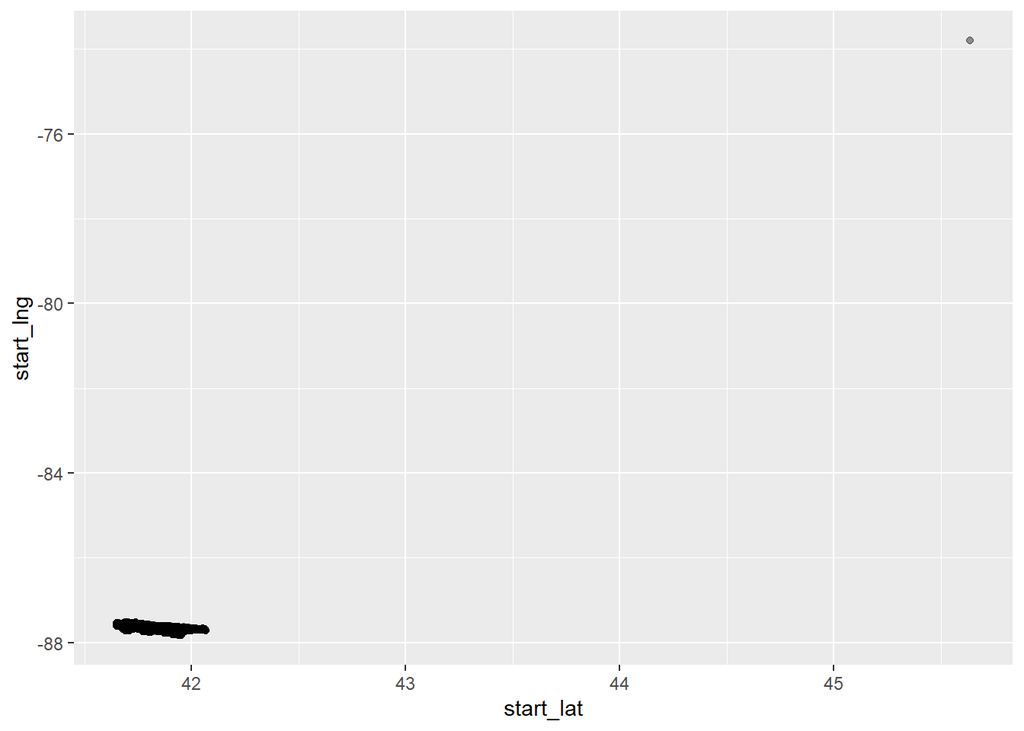

```r
scatterplot1 <- ggplot(trip_clean4, aes(x=start_lat, y=start_lng))+
  geom_jitter(alpha = 0.4)
scatterplot1
```

The points are cluttered between $41.5^{\circ}$ and $42.5^{\circ}$ latitude and an outlier is at `start_lat>45`.

Another scatter plot is made with the `end_lat` as the horizontal values and `end_lng` as the vertical values. The same with the first scatterplot, outliers are identified where `end_lat` and `end_lng` are both zero.

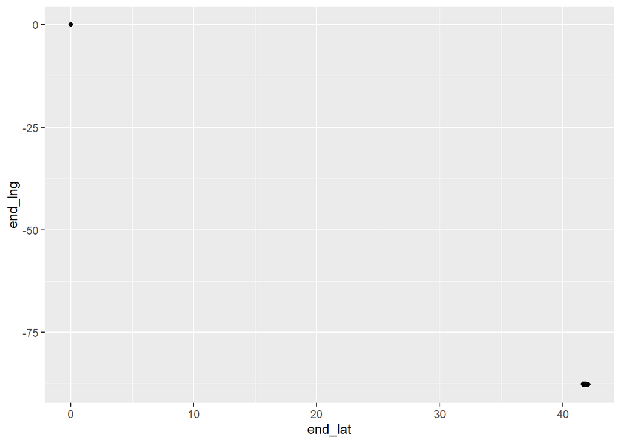

```r
scatterplot2 <- ggplot(trip_clean4, aes(x=end_lat, y=end_lng))+
  geom_jitter(alpha = 0.4)
scatterplot2
```

The [border coordinates](https://en.wikipedia.org/wiki/Module:Location_map/data/United_States_Chicago) of Chicago for latitudes are $41.9653^{\circ}$(top) and $41.8096^{\circ}$(bottom) and for longitudes $-87.7738^{\circ}$(left) and $-87.5658^{\circ}$(right). These outliers are removed, 9 rows are deleted.

```r
trip_clean5 <- trip_clean4 %>%
  filter(end_lat!=0) %>%
  filter(between(start_lat, 41.5, 42.5))
head(trip_clean5)
```

```
## # A tibble: 6 × 11
##   ride_id        ridea…¹ started_at          ended_at            start…² end_s…³
##   <chr>          <fct>   <dttm>              <dttm>              <fct>   <fct>
## 1 46F8167220E44… electr… 2021-12-07 15:06:07 2021-12-07 15:13:42 13307   TA1307…
## 2 73A77762838B3… electr… 2021-12-11 03:43:29 2021-12-11 04:10:23 KP1705… TA1307…
## 3 4CF42452054F5… electr… 2021-12-15 23:10:28 2021-12-15 23:23:14 KA1504… 13137
## 4 3278BA87BF698… classi… 2021-12-26 16:16:10 2021-12-26 16:30:53 KA1504… KP1705…
## 5 6FF54232576A3… electr… 2021-12-30 11:31:05 2021-12-30 11:51:21 18058   TA1307…
## 6 93E8D79490E3A… classi… 2021-12-01 18:28:36 2021-12-01 18:38:03 SL-012  SL-011
## # … with 5 more variables: start_lat <dbl>, start_lng <dbl>, end_lat <dbl>,
## #   end_lng <dbl>, member_casual <fct>, and abbreviated variable names
## #   ¹rideable_type, ²start_station_id, ³end_station_id
```

### Addition of new variables

The initial time of ride, represented by the variable `started_at`, and the final time of ride, represented by the variable `ended_at`, are POSIXct date times. A new variable is added which measures the duration of a trip. It is the difference between `ended_at` and `started_at`. Negative duration were discarded, 69 rows are deleted.

```r
trip_new1 <- trip_clean5 %>%
  mutate(ride_length = int_length(interval(started_at, ended_at)),
         .after = ended_at) %>%
  filter(ride_length >= 0)
head(trip_new1)
```

```
## # A tibble: 6 × 12
##   ride_id        ridea…¹ started_at          ended_at            ride_…² start…³
##   <chr>          <fct>   <dttm>              <dttm>                <dbl> <fct>
## 1 46F8167220E44… electr… 2021-12-07 15:06:07 2021-12-07 15:13:42     455 13307
## 2 73A77762838B3… electr… 2021-12-11 03:43:29 2021-12-11 04:10:23    1614 KP1705…
## 3 4CF42452054F5… electr… 2021-12-15 23:10:28 2021-12-15 23:23:14     766 KA1504…
## 4 3278BA87BF698… classi… 2021-12-26 16:16:10 2021-12-26 16:30:53     883 KA1504…
## 5 6FF54232576A3… electr… 2021-12-30 11:31:05 2021-12-30 11:51:21    1216 18058
## 6 93E8D79490E3A… classi… 2021-12-01 18:28:36 2021-12-01 18:38:03     567 SL-012
## # … with 6 more variables: end_station_id <fct>, start_lat <dbl>,
## #   start_lng <dbl>, end_lat <dbl>, end_lng <dbl>, member_casual <fct>, and
## #   abbreviated variable names ¹rideable_type, ²ride_length, ³start_station_id
```

Two columns are added which are the day and month of the starting datetime of a ride. The new columns are ordered factor data types.

```r
trip_data <- trip_new1 %>%
  mutate(day_of_week = wday(started_at, label = TRUE, abbr = FALSE),
         month_of_year = month(started_at, label = TRUE, abbr = FALSE))
head(trip_data)
```

```
## # A tibble: 6 × 14
##   ride_id        ridea…¹ started_at          ended_at            ride_…² start…³
##   <chr>          <fct>   <dttm>              <dttm>                <dbl> <fct>
## 1 46F8167220E44… electr… 2021-12-07 15:06:07 2021-12-07 15:13:42     455 13307
## 2 73A77762838B3… electr… 2021-12-11 03:43:29 2021-12-11 04:10:23    1614 KP1705…
## 3 4CF42452054F5… electr… 2021-12-15 23:10:28 2021-12-15 23:23:14     766 KA1504…
## 4 3278BA87BF698… classi… 2021-12-26 16:16:10 2021-12-26 16:30:53     883 KA1504…
## 5 6FF54232576A3… electr… 2021-12-30 11:31:05 2021-12-30 11:51:21    1216 18058
## 6 93E8D79490E3A… classi… 2021-12-01 18:28:36 2021-12-01 18:38:03     567 SL-012
## # … with 8 more variables: end_station_id <fct>, start_lat <dbl>,
## #   start_lng <dbl>, end_lat <dbl>, end_lng <dbl>, member_casual <fct>,
## #   day_of_week <ord>, month_of_year <ord>, and abbreviated variable names
## #   ¹rideable_type, ²ride_length, ³start_station_id
```

After processing and cleaning the raw data, a summary for the cleaned data set is shown:

```r
skim_without_charts(trip_data)
```

Data summary

| Name | trip_data |
| --- | --- |
| Number of rows | 4410250 |
| Number of columns | 14 |
| _______________________ |  |
| Column type frequency: |  |
| character | 1 |
| factor | 6 |
| numeric | 5 |
| POSIXct | 2 |
| ________________________ |  |
| Group variables | None |

**Variable type: character**

| skim_variable | n_missing | complete_rate | min | max | empty | n_unique | whitespace |
| --- | --- | --- | --- | --- | --- | --- | --- |
| ride_id | 0 | 1 | 16 | 16 | 0 | 4410250 | 0 |

**Variable type: factor**

| skim_variable | n_missing | complete_rate | ordered | n_unique | top_counts |
| --- | --- | --- | --- | --- | --- |
| rideable_type | 0 | 1 | FALSE | 3 | cla: 2624392, ele: 1607994, doc: 177864 |
| start_station_id | 0 | 1 | FALSE | 1255 | 130: 71956, 133: 39996, LF-: 37959, 130: 37540 |
| end_station_id | 0 | 1 | FALSE | 1271 | 130: 73363, LF-: 40785, 133: 39036, 130: 38654 |
| member_casual | 0 | 1 | FALSE | 2 | mem: 2638532, cas: 1771718 |
| day_of_week | 0 | 1 | TRUE | 7 | Sat: 709070, Thu: 653453, Wed: 629044, Fri: 618825 |
| month_of_year | 0 | 1 | TRUE | 12 | Jul: 642666, Jun: 620348, Aug: 605313, Sep: 535140 |

**Variable type: numeric**

| skim_variable | n_missing | complete_rate | mean | sd | p0 | p25 | p50 | p75 | p100 |
| --- | --- | --- | --- | --- | --- | --- | --- | --- | --- |
| ride_length | 0 | 1 | 1029.58 | 3244.93 | 0.00 | 364.00 | 637.00 | 1143.00 | 2061244.00 |
| start_lat | 0 | 1 | 41.90 | 0.04 | 41.65 | 41.88 | 41.90 | 41.93 | 42.06 |
| start_lng | 0 | 1 | -87.64 | 0.02 | -87.83 | -87.66 | -87.64 | -87.63 | -87.53 |
| end_lat | 0 | 1 | 41.90 | 0.04 | 41.65 | 41.88 | 41.90 | 41.93 | 42.06 |
| end_lng | 0 | 1 | -87.65 | 0.03 | -87.83 | -87.66 | -87.64 | -87.63 | -87.53 |

**Variable type: POSIXct**

| skim_variable | n_missing | complete_rate | min | max | median | n_unique |
| --- | --- | --- | --- | --- | --- | --- |
| started_at | 0 | 1 | 2021-12-01 00:00:03 | 2022-11-30 23:56:11 | 2022-07-12 22:13:28 | 3818819 |
| ended_at | 0 | 1 | 2021-12-01 00:07:34 | 2022-12-01 11:45:53 | 2022-07-12 22:29:48 | 3831807 |

## **Data analysis**

### Statistical summary based on membership type

The mean, median, minimum and maximum ride length of the data based on membership type is presented.

```r
trip_data %>%
  group_by(member_casual) %>%
  summarise(mean = mean(ride_length), median = median(ride_length),
          min = min(ride_length), max = max(ride_length))
```

```
## # A tibble: 2 × 5
##   member_casual  mean median   min     max
##   <fct>         <dbl>  <dbl> <dbl>   <dbl>
## 1 casual        1451.    835     0 2061244
## 2 member         747.    539     0   89594
```

The mean and median of the length of ride is greater for casual riders. The maximum time of ride is also greater for casual riders. It can be concluded that riders that have annual membership spent lesser time per ride. Annual member rides are bounded by time restrictions as a reason for their shorter length of ride. Casual riders have more free time, their rides are spent in a leisurely manner.

### Number of rides per member type

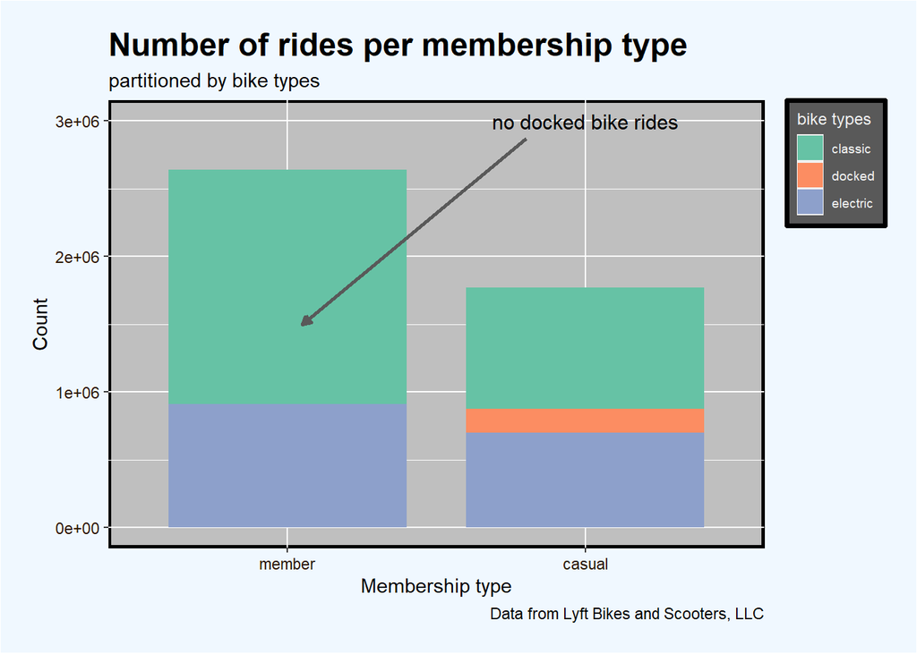

```r
ggplot(trip_data, aes(x = member_casual, fill = rideable_type))+
  geom_bar(width = 0.8)+
  scale_fill_brewer(type = "qual",
                    palette = "Set2",
                    labels = c("classic", "docked", "electric"))+
  labs(title = "Number of rides per membership type",
       subtitle = "partitioned by bike types",
       x = "Membership type",
       y = "Count",
       fill = "bike types",
       caption = "Data from Lyft Bikes and Scooters, LLC"
       )+
  theme1+
  annotate("text", x = 2,
           y = 3000000,
           label = "no docked bike rides",
           size = 4)+
  annotate("segment", xend = 1.05,
           yend =1500000,
           x = 1.8,
           y = 2870000,
           linewidth = 0.9,
           color = "#595959",
           arrow = arrow(length = unit(5, "pt"), type = "closed")
  )
```

From December of 2021 up to November of 2022, there are lesser casual rides. The number of electric and classic bike use for casual riders do not differ greatly but noticeably, there are more classic bike rides for annual members. There are no docked bike usage for annual members. Classic bike use for annual members can be prioritized mainly and next is electric bike use.

### Mean ride duration each day

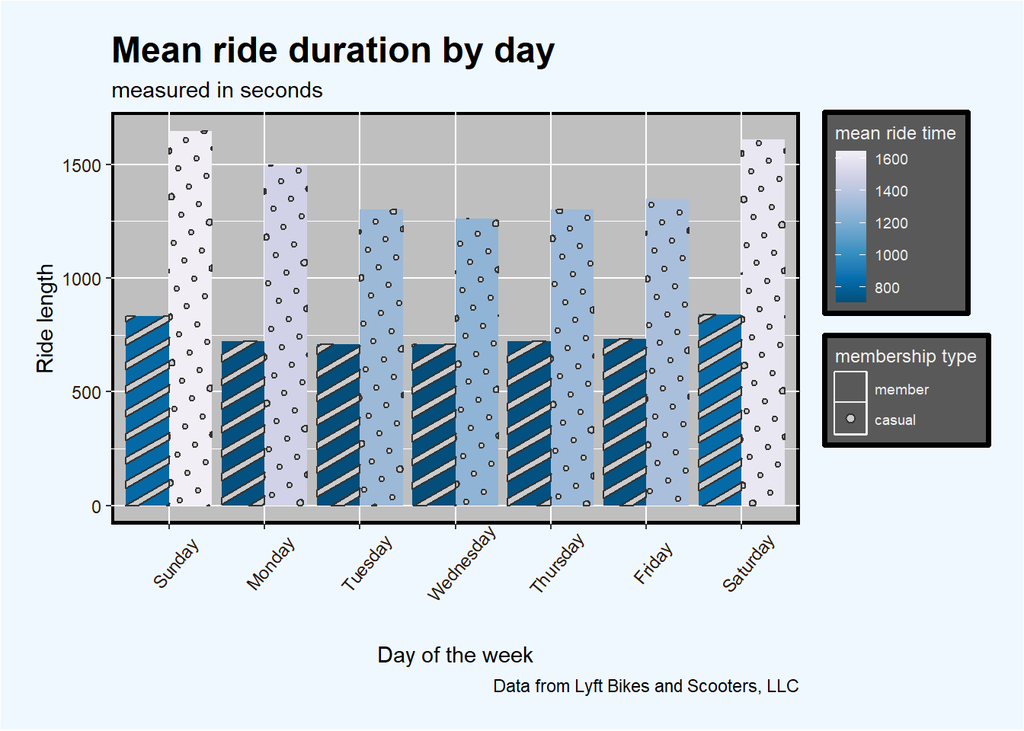

```r
trip_data_summ1 <- trip_data %>%
  group_by(day_of_week, member_casual) %>%
  summarise(mean_ride_length = mean(ride_length))

ggplot(trip_data_summ1, aes(x = day_of_week, y = mean_ride_length, fill = mean_ride_length, pattern = member_casual))+
  geom_col_pattern(position = "dodge", pattern_density =0.3)+
  scale_fill_distiller(type = "seq", palette = "PuBu")+
  labs(title = "Mean ride duration by day",
       subtitle = "measured in seconds",
       x = "Day of the week",
       y = "Ride length",
       fill = "mean ride time",
       pattern = "membership type",
       caption = "Data from Lyft Bikes and Scooters, LLC"
  )+
  theme1+
  theme2
```

For any day of the week, the mean ride time for casual riders is always greater than annual members. There is an increase in ride time on Sunday and Saturday both for casual and member ridership but only a slight change for annual members. Ride time in a day increases and reaches its peak as the weekend approaches. Annual members ride time per day do not vary widely, this is an indicator that they use Cyclistic bikes steadily in a week.

### Mean number of rider each day

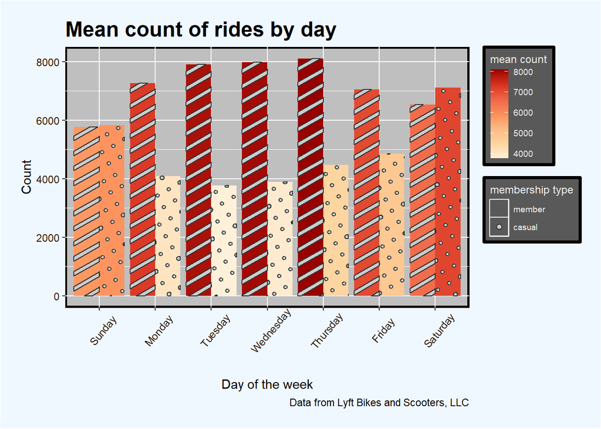

```r
trip_data_summ2 <- trip_data %>%
  mutate(day_date_fac = as.factor(date(started_at))) %>%
  group_by(day_of_week, member_casual) %>%
  summarise(mean_count = n()/n_distinct(day_date_fac))

ggplot(trip_data_summ2, aes(x = day_of_week, y = mean_count, fill = mean_count, pattern = member_casual))+
  geom_col_pattern(position = "dodge", pattern_density =0.3)+
  scale_fill_distiller(type = "seq", palette = "OrRd", direction = 1)+
  labs(title = "Mean count of rides by day",
       x = "Day of the week",
       y = "Count",
       fill = "mean count",
       pattern = "membership type",
       caption = "Data from Lyft Bikes and Scooters, LLC"
  )+
  theme2+
  theme1
```

The average count of rides is significantly higher for riders with annual memberships on weekdays when compared with the average count of rides for casual riders. As the average count of rides for members decreases on weekends while increases for casual riders, the difference in average count of rides on weekends is not huge. For casual rides, the trend is similar with its trend on mean ride duration. There is a higher count of casual rides on weekends.

### Total number of rides each month

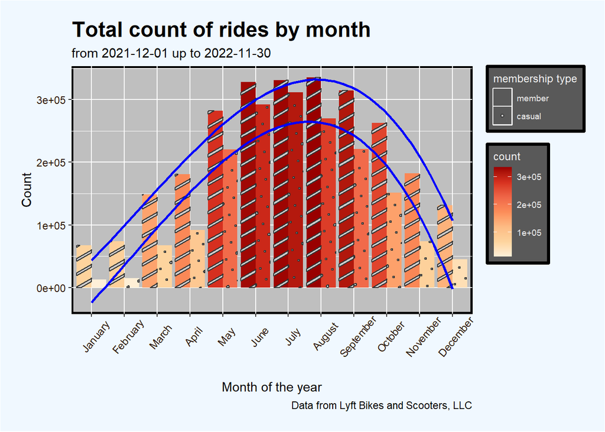

```r
trip_data_summ4 <- trip_data %>%
  group_by(month_of_year, member_casual) %>%
  summarise(count_by_m = n())

ggplot(trip_data_summ4, aes(x = month_of_year, y = count_by_m, fill = count_by_m, pattern = member_casual))+
  geom_col_pattern(position = "dodge")+
  scale_fill_distiller(type = "seq", palette = "OrRd", direction = 1)+
  labs(title = "Total count of rides by month",
       subtitle = "from 2021-12-01 up to 2022-11-30",
       x = "Month of the year",
       y = "Count",
       fill = "count",
       pattern = "membership type",
       caption = "Data from Lyft Bikes and Scooters, LLC"
  )+
  theme2+
  theme1+
  geom_smooth(aes(group = member_casual),method = lm,
              formula = y ~ splines::bs(x, 3),
              se = FALSE,
              color = "blue", alpha = 0.8)
```

For both casual and member rides, the count of rides are highest on the months of May up to September. The lowest number of rides for both membership types are on the months of January, February and December. The counts of rides for members and casual riders have similar trends.

### Data analysis based on initial and final ride locations

#### Data aggregation for Tableau

The data set is aggregated showing counts of ride by path taken(from initial station id to final station id), it is also grouped by membership type.

```r
trip_data_agg <- trip_data %>%
  group_by(start_station_id, end_station_id, member_casual) %>%
  summarise(id_count = n(),
            initial_lat = mean(start_lat),
            initial_lng = mean(start_lng),
            final_lat = mean(end_lat),
            final_lng = mean(end_lng))
head(trip_data_agg)
```

```
## # A tibble: 6 × 8
## # Groups:   start_station_id, end_station_id [5]
##   start_station_id end_station…¹ membe…² id_co…³ initi…⁴ initi…⁵ final…⁶ final…⁷
##   <fct>            <fct>         <ord>     <int>   <dbl>   <dbl>   <dbl>   <dbl>
## 1 021320           021320        member       13    41.9   -87.7    41.9   -87.7
## 2 021320           021320        casual        9    41.9   -87.7    41.9   -87.7
## 3 021320           1019          member        4    41.9   -87.7    41.9   -87.7
## 4 021320           1062          casual        1    41.9   -87.7    41.9   -87.7
## 5 021320           13001         casual        1    41.9   -87.7    41.9   -87.6
## 6 021320           13011         member        1    41.9   -87.7    41.9   -87.6
## # … with abbreviated variable names ¹end_station_id, ²member_casual, ³id_count,
## #   ⁴initial_lat, ⁵initial_lng, ⁶final_lat, ⁷final_lng
```

##### **Density map for the overall data**

[figure not shown]

```r
include_graphics("density_map_all.png")
```

For the data including both annual members and casual riders, the start station ids are concentrated about the center of the town.

##### **Density map for annual members**

[figure not shown]

```r
include_graphics("density_map_member.png")
```

For the data including annual members only, the start station ids are also concentrated about the center of the town.

##### **Density map for casual riders**

[figure not shown]

```r
include_graphics("density_map_casual.png")
```

For the data including casual riders only, the same pattern can be observed.

##### **Top routes for annual members**

[figure not shown]

```r
include_graphics("routes_member.png")
```

Notice that routes with the highest count of rides are scattered around the town.

##### **Top routes for casual riders**

[figure not shown]

```r
include_graphics("routes_casual.png")
```

Notice that routes of casual riders are dense about the center of the town which is the same pattern as the volume of rides for casual riders.

## **Recommendations**

Based on the results of the data analysis here are the top recommendations on how casual riders would be encouraged to avail the annual subscription:

1. Riders with **annual memberships** tend to use bikes for **commuting** as described by the low ride time for them while casual tend to use the bikes for a longer period of time for leisurely manner. The greater volume of riders with annual membership on **weekdays** also signifies a strong correlation on using of Cyclistic bikes as a mode of transportation to **work**. The marketing team can tend toward promoting using Cyclistic bikes as a primary **commute transportation**.
2. Ride volume is larger on the months of **May up to September** when compared to the other months. Further data analysis should be conducted to identify **trends** on the monthly count of rides per annum to be able to make future marketing strategies based on the **monthly behavior** of users.
3. Casual rides are highly concentrated at the **center** of the town. As to convert majority of the casual riders to annual members, prioritization of marketing strategies based on location should be administered on the **center** of the town.